# ltm vs. mirt (2)

Piotr Król

18 06 2021

Content:

- 5x5 matrix
- Baker&Kim matrices
- 50x5 random matrix
- LSAT7
- 100X5 random matrix
- CDI items params
- CDI CAT simulations

```r
library(ltm)
library(mirt)
library(mirtCAT)
library(parallel) #Speed up simulations
library(plyr) #For laply
library(ggpubr)
```

## 5x5 matrix

Let’s take again matrix (second one) from last report:

```r
responses <- rbind(
  c(1,0,1,0,1),
  c(0,1,0,1,0),
  c(1,0,1,0,1),
  c(0,1,0,1,0),
  c(1,1,0,0,1)
)
colnames(responses) <- paste0("item", c(1:5)) #needded for mirt
responses
```

```
##      item1 item2 item3 item4 item5
## [1,]     1     0     1     0     1
## [2,]     0     1     0     1     0
## [3,]     1     0     1     0     1
## [4,]     0     1     0     1     0
## [5,]     1     1     0     0     1
```

And according to https://groups.google.com/g/mirt-package/c/yLV12DSVj2A check confidence intervals for parameters:

```r
mirt_model <- mirt(responses, 1, SE=TRUE)
```

```r
coef(mirt_model)
```

```
## $item1
##                a1         d  g  u
## par        143.30    42.922  0  1
## CI_2.5  -29841.75 -9462.986 NA NA
## CI_97.5  30128.35  9548.830 NA NA
##
## $item2
##                 a1          d  g  u
## par       -150.145     44.769  0  1
## CI_2.5  -42784.180 -12622.643 NA NA
## CI_97.5  42483.889  12712.182 NA NA
##
## $item3
##                 a1          d  g  u
## par        150.145    -44.769  0  1
## CI_2.5  -42483.935 -12712.160 NA NA
## CI_97.5  42784.226  12622.622 NA NA
##
## $item4
##                 a1         d  g  u
## par       -143.302   -42.921  0  1
## CI_2.5  -30130.321 -9545.048 NA NA
## CI_97.5  29843.718  9459.207 NA NA
##
## $item5
##                a1         d  g  u
## par        143.30    42.922  0  1
## CI_2.5  -29841.75 -9462.986 NA NA
## CI_97.5  30128.35  9548.830 NA NA
##
## $GroupPars
##         MEAN_1 COV_11
## par          0      1
## CI_2.5      NA     NA
## CI_97.5     NA     NA
```

They are in fact pretty wide. Let’s look at item characteristic curves:

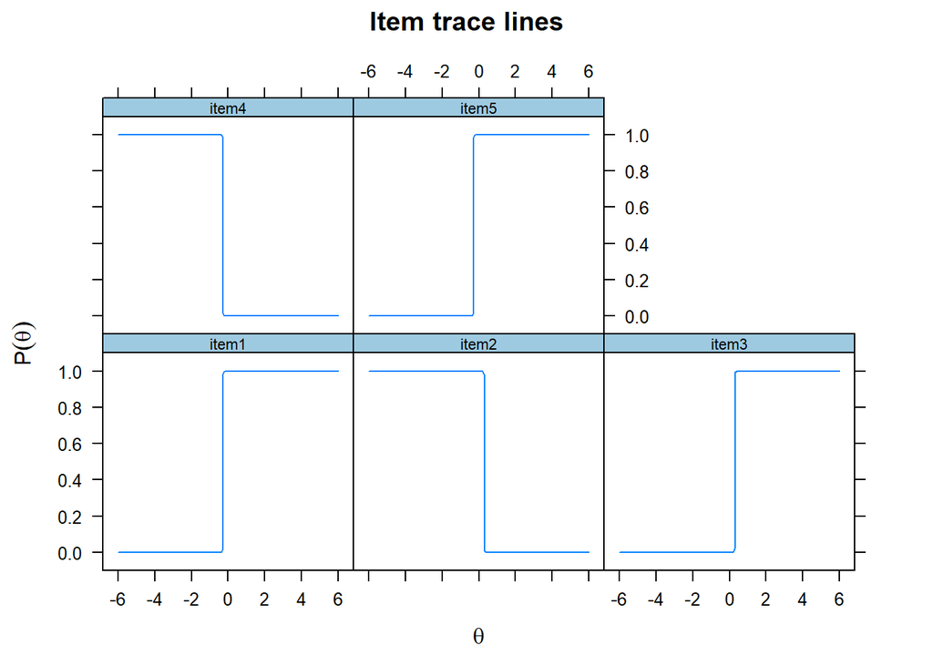

```r
plot(mirt_model, type = 'trace')
```

They don’t look good. Let’s look for a “numerically stable” model and check if in such a case parameters would be similar.

## Baker & Kim matrices (ch. 7)

I will take matrix from Baker & Kim (2017, p.116):

```r
N <- 16
J <- 10
U <- matrix(c(
0, 0, 1, 0, 0, 0, 0, 1, 0, 0,
1, 0, 1, 0, 0, 0, 0, 0, 0, 0,
1, 1, 1, 0, 1, 0, 1, 0, 0, 0,
1, 1, 1, 0, 1, 0, 0, 0, 0, 0,
0, 0, 0, 0, 1, 0, 0, 0, 0, 0,
1, 1, 0, 1, 0, 0, 0, 0, 0, 0,
1, 0, 0, 0, 0, 1, 1, 1, 0, 0,
1, 0, 0, 0, 1, 1, 0, 0, 1, 0,
1, 0, 1, 0, 0, 1, 0, 0, 1, 0,
1, 0, 0, 0, 1, 0, 0, 0, 1, 0,
1, 1, 0, 1, 1, 1, 1, 1, 1, 1,
1, 1, 1, 1, 1, 1, 1, 1, 1, 0,
1, 1, 1, 0, 1, 0, 1, 0, 0, 1,
1, 1, 1, 1, 1, 1, 1, 1, 1, 0,
1, 1, 0, 1, 1, 1, 1, 1, 1, 1,
1, 1, 1, 1, 1, 1, 1, 1, 1, 1
), nrow=N, ncol=J, byrow=TRUE)
colnames(U) <- paste0("item", c(1:J))
U
```

```
##       item1 item2 item3 item4 item5 item6 item7 item8 item9 item10
##  [1,]     0     0     1     0     0     0     0     1     0      0
##  [2,]     1     0     1     0     0     0     0     0     0      0
##  [3,]     1     1     1     0     1     0     1     0     0      0
##  [4,]     1     1     1     0     1     0     0     0     0      0
##  [5,]     0     0     0     0     1     0     0     0     0      0
##  [6,]     1     1     0     1     0     0     0     0     0      0
##  [7,]     1     0     0     0     0     1     1     1     0      0
##  [8,]     1     0     0     0     1     1     0     0     1      0
##  [9,]     1     0     1     0     0     1     0     0     1      0
## [10,]     1     0     0     0     1     0     0     0     1      0
## [11,]     1     1     0     1     1     1     1     1     1      1
## [12,]     1     1     1     1     1     1     1     1     1      0
## [13,]     1     1     1     0     1     0     1     0     0      1
## [14,]     1     1     1     1     1     1     1     1     1      0
## [15,]     1     1     0     1     1     1     1     1     1      1
## [16,]     1     1     1     1     1     1     1     1     1      1
```

```r
mirt_model <- mirt(U, 1, SE=TRUE)
```

```
## EM cycles terminated after 500 iterations.
```

```r
mirt_model
```

```
##
## Call:
## mirt(data = U, model = 1, SE = TRUE)
##
## Full-information item factor analysis with 1 factor(s).
## FAILED TO CONVERGE within 1e-04 tolerance after 500 EM iterations.
## mirt version: 1.33.2
## M-step optimizer: BFGS
## EM acceleration: Ramsay
## Number of rectangular quadrature: 61
## Latent density type: Gaussian
##
## Information matrix estimated with method: Oakes
## Second-order test: model is a possible local maximum
## Condition number of information matrix =  56408.77
##
## Log-likelihood = -79.60143
## Estimated parameters: 20
## AIC = 199.2029; AICc = 31.20285
## BIC = 214.6546; SABIC = 153.4492
## G2 (1003) = 76.03, p = 1
## RMSEA = 0, CFI = NaN, TLI = NaN
```

*mirt* fails to converge. I have probably to remove ceiling subject (16th):

```r
U <- U[-c(16), ]
U
```

```
##       item1 item2 item3 item4 item5 item6 item7 item8 item9 item10
##  [1,]     0     0     1     0     0     0     0     1     0      0
##  [2,]     1     0     1     0     0     0     0     0     0      0
##  [3,]     1     1     1     0     1     0     1     0     0      0
##  [4,]     1     1     1     0     1     0     0     0     0      0
##  [5,]     0     0     0     0     1     0     0     0     0      0
##  [6,]     1     1     0     1     0     0     0     0     0      0
##  [7,]     1     0     0     0     0     1     1     1     0      0
##  [8,]     1     0     0     0     1     1     0     0     1      0
##  [9,]     1     0     1     0     0     1     0     0     1      0
## [10,]     1     0     0     0     1     0     0     0     1      0
## [11,]     1     1     0     1     1     1     1     1     1      1
## [12,]     1     1     1     1     1     1     1     1     1      0
## [13,]     1     1     1     0     1     0     1     0     0      1
## [14,]     1     1     1     1     1     1     1     1     1      0
## [15,]     1     1     0     1     1     1     1     1     1      1
```

```r
mirt_model <- mirt(U, 1, SE=TRUE)
```

```
## EM cycles terminated after 500 iterations.
```

```r
mirt_model
```

```
##
## Call:
## mirt(data = U, model = 1, SE = TRUE)
##
## Full-information item factor analysis with 1 factor(s).
## FAILED TO CONVERGE within 1e-04 tolerance after 500 EM iterations.
## mirt version: 1.33.2
## M-step optimizer: BFGS
## EM acceleration: Ramsay
## Number of rectangular quadrature: 61
## Latent density type: Gaussian
##
## Information matrix estimated with method: Oakes
## Second-order test: model is a possible local maximum
## Condition number of information matrix =  42499.37
##
## Log-likelihood = -76.64209
## Estimated parameters: 20
## AIC = 193.2842; AICc = 53.28417
## BIC = 207.4452; SABIC = 146.3874
## G2 (1003) = 77.59, p = 1
## RMSEA = 0, CFI = NaN, TLI = NaN
```

Still fails to converge but there are no any ceiling or floor items/subjects:

```r
rowSums(U)
```

```
##  [1] 2 2 5 4 1 3 4 4 4 3 9 9 6 9 9
```

```r
colSums(U)
```

```
##  item1  item2  item3  item4  item5  item6  item7  item8  item9 item10
##     13      8      8      5     10      7      7      6      7      3
```

Let’s take second matrix from Baker & Kim (2017, p.117):

```r
N <- 16
J <- 10
U2 <- matrix(c(
0, 0, 1, 0, 0, 0, 0, 0, 0, 0,
0, 1, 1, 1, 0, 0, 0, 1, 0, 0,
1, 0, 0, 1, 0, 0, 0, 0, 0, 0,
1, 1, 1, 0, 0, 0, 1, 0, 0, 1,
1, 1, 1, 1, 0, 0, 0, 0, 0, 1,
1, 1, 1, 0, 1, 1, 0, 0, 0, 1,
1, 1, 1, 1, 1, 1, 1, 1, 1, 0,
1, 1, 1, 0, 1, 1, 1, 0, 0, 0,
0, 1, 1, 1, 1, 1, 0, 1, 1, 0,
1, 0, 1, 1, 1, 1, 1, 0, 1, 0,
1, 1, 1, 1, 1, 0, 0, 1, 0, 1,
1, 1, 1, 1, 1, 0, 1, 1, 1, 0,
1, 1, 1, 0, 1, 1, 0, 0, 0, 0,
1, 1, 1, 0, 1, 1, 1, 1, 1, 1,
1, 1, 1, 1, 1, 1, 1, 1, 1, 1,
1, 1, 1, 1, 1, 1, 1, 1, 1, 1
), nrow=N, ncol=J, byrow=TRUE)
colnames(U2) <- paste0("item", c(1:J))
U2
```

```
##       item1 item2 item3 item4 item5 item6 item7 item8 item9 item10
##  [1,]     0     0     1     0     0     0     0     0     0      0
##  [2,]     0     1     1     1     0     0     0     1     0      0
##  [3,]     1     0     0     1     0     0     0     0     0      0
##  [4,]     1     1     1     0     0     0     1     0     0      1
##  [5,]     1     1     1     1     0     0     0     0     0      1
##  [6,]     1     1     1     0     1     1     0     0     0      1
##  [7,]     1     1     1     1     1     1     1     1     1      0
##  [8,]     1     1     1     0     1     1     1     0     0      0
##  [9,]     0     1     1     1     1     1     0     1     1      0
## [10,]     1     0     1     1     1     1     1     0     1      0
## [11,]     1     1     1     1     1     0     0     1     0      1
## [12,]     1     1     1     1     1     0     1     1     1      0
## [13,]     1     1     1     0     1     1     0     0     0      0
## [14,]     1     1     1     0     1     1     1     1     1      1
## [15,]     1     1     1     1     1     1     1     1     1      1
## [16,]     1     1     1     1     1     1     1     1     1      1
```

```r
mirt_model <- mirt(U2, 1, SE=TRUE)
```

```
## EM cycles terminated after 500 iterations.
```

```r
mirt_model
```

```
##
## Call:
## mirt(data = U2, model = 1, SE = TRUE)
##
## Full-information item factor analysis with 1 factor(s).
## FAILED TO CONVERGE within 1e-04 tolerance after 500 EM iterations.
## mirt version: 1.33.2
## M-step optimizer: BFGS
## EM acceleration: Ramsay
## Number of rectangular quadrature: 61
## Latent density type: Gaussian
##
## Information matrix estimated with method: Oakes
## Second-order test: model is a possible local maximum
## Condition number of information matrix =  115519.6
##
## Log-likelihood = -77.06216
## Estimated parameters: 20
## AIC = 194.1243; AICc = 26.12431
## BIC = 209.5761; SABIC = 148.3707
## G2 (1003) = 68.17, p = 1
## RMSEA = 0, CFI = NaN, TLI = NaN
```

This also fails to converge.

## 50x5 random matrix

Let’s generate some matrix (50x5) randomly filled with 0s and 1s:

```r
r = 50
c = 5
responses <- matrix(rbinom(r*c,1,0.5),r,c)
colnames(responses) <- paste0("item", c(1:c))
```

```r
head(responses)
```

```
##      item1 item2 item3 item4 item5
## [1,]     0     1     0     0     1
## [2,]     1     0     1     0     0
## [3,]     1     0     1     1     0
## [4,]     0     0     1     1     1
## [5,]     1     0     0     1     0
## [6,]     1     0     0     0     0
```

```r
colSums(responses)
```

```
## item1 item2 item3 item4 item5
##    25    21    24    21    26
```

```r
rowSums(responses)
```

```
##  [1] 2 2 3 3 2 1 3 2 3 3 5 4 1 3 2 3 1 3 3 3 3 2 3 1 2 1 3 2 3 3 0 2 2 1 3 1 2 3
## [39] 5 1 1 3 3 2 2 0 4 4 1 2
```

And create *mirt* model:

```r
mirt_model <- mirt(responses, 1, SE=TRUE)
```

```r
mirt_model
```

```
##
## Call:
## mirt(data = responses, model = 1, SE = TRUE)
##
## Full-information item factor analysis with 1 factor(s).
## Converged within 1e-04 tolerance after 164 EM iterations.
## mirt version: 1.33.2
## M-step optimizer: BFGS
## EM acceleration: Ramsay
## Number of rectangular quadrature: 61
## Latent density type: Gaussian
##
## Information matrix estimated with method: Oakes
## Second-order test: model is a possible local maximum
## Condition number of information matrix =  217.8946
##
## Log-likelihood = -169.8465
## Estimated parameters: 10
## AIC = 359.693; AICc = 365.334
## BIC = 378.8132; SABIC = 347.4249
## G2 (21) = 21.31, p = 0.4401
## RMSEA = 0.017, CFI = NaN, TLI = NaN
```

Now succesfully converged. Let’s look at parameters:

```r
coef(mirt_model)
```

```
## $item1
##             a1      d  g  u
## par     -0.926  0.001  0  1
## CI_2.5  -4.498 -0.656 NA NA
## CI_97.5  2.646  0.657 NA NA
##
## $item2
##             a1      d  g  u
## par      0.151 -0.324  0  1
## CI_2.5  -1.006 -0.890 NA NA
## CI_97.5  1.309  0.241 NA NA
##
## $item3
##             a1      d  g  u
## par     -0.481 -0.084  0  1
## CI_2.5  -2.087 -0.670 NA NA
## CI_97.5  1.125  0.501 NA NA
##
## $item4
##             a1      d  g  u
## par      1.507 -0.459  0  1
## CI_2.5  -5.851 -1.795 NA NA
## CI_97.5  8.865  0.878 NA NA
##
## $item5
##             a1      d  g  u
## par      0.447  0.084  0  1
## CI_2.5  -0.965 -0.498 NA NA
## CI_97.5  1.859  0.665 NA NA
##
## $GroupPars
##         MEAN_1 COV_11
## par          0      1
## CI_2.5      NA     NA
## CI_97.5     NA     NA
```

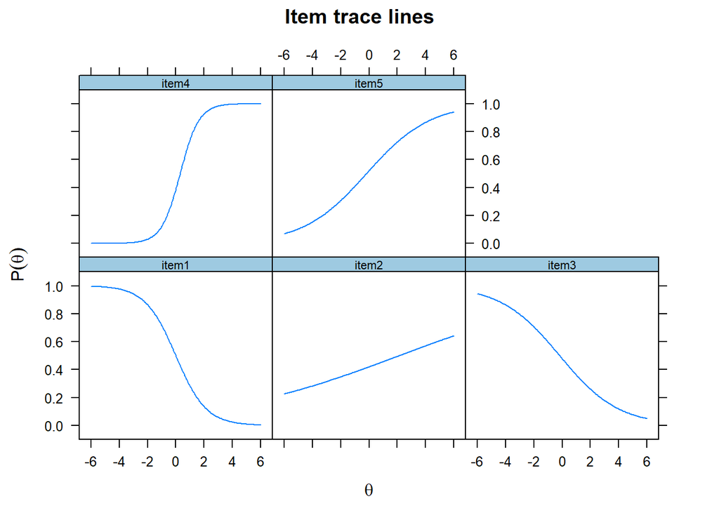

```r
plot(mirt_model, type = 'trace')
```

```r
itemfit(mirt_model)
```

```
##    item  S_X2 df.S_X2 RMSEA.S_X2 p.S_X2
## 1 item1 2.740       1      0.188  0.098
## 2 item2 0.444       1      0.000  0.505
## 3 item3 1.774       1      0.126  0.183
## 4 item4 0.012       1      0.000  0.913
## 5 item5 0.042       1      0.000  0.838
```

So it looks like curves are generally fitting (maybe except 1st).

Let’s check for *ltm*:

```r
(ltm_model <- ltm(responses ~ z1, IRT.param = FALSE))
```

```
##
## Call:
## ltm(formula = responses ~ z1, IRT.param = FALSE)
##
## Coefficients:
##        (Intercept)      z1
## item1        0.000   0.914
## item2       -0.324  -0.149
## item3       -0.084   0.476
## item4       -0.462  -1.535
## item5        0.084  -0.451
##
## Log.Lik: -169.846
```

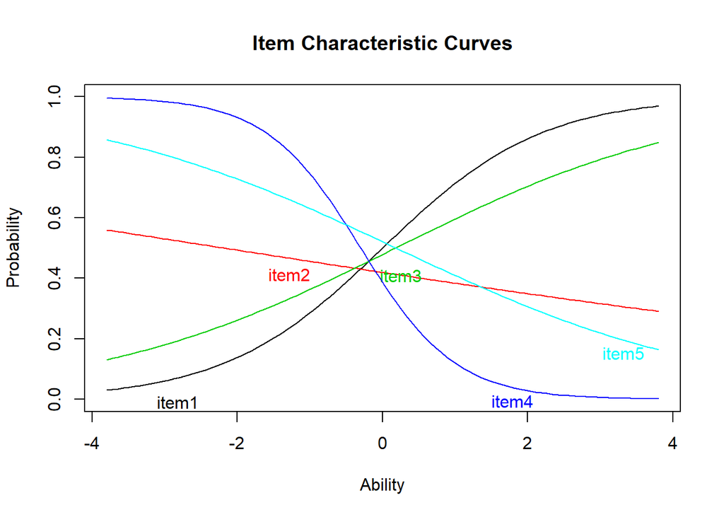

```r
plot(ltm_model)
```

So it looks like parameters are similar but slopes have opposite sign??

## LSAT7

Let’s check on LSAT7 dataset:

```r
responses <- expand.table(LSAT7)
head(responses)
```

```
##   Item.1 Item.2 Item.3 Item.4 Item.5
## 1      0      0      0      0      0
## 2      0      0      0      0      0
## 3      0      0      0      0      0
## 4      0      0      0      0      0
## 5      0      0      0      0      0
## 6      0      0      0      0      0
```

```r
dim(responses)
```

```
## [1] 1000    5
```

```r
mirt_model <- mirt(responses, 1, SE=TRUE)
```

```r
coef(mirt_model)
```

```
## $Item.1
##            a1     d  g  u
## par     0.988 1.856  0  1
## CI_2.5  0.641 1.598 NA NA
## CI_97.5 1.335 2.114 NA NA
##
## $Item.2
##            a1     d  g  u
## par     1.081 0.808  0  1
## CI_2.5  0.750 0.629 NA NA
## CI_97.5 1.412 0.987 NA NA
##
## $Item.3
##            a1     d  g  u
## par     1.706 1.804  0  1
## CI_2.5  1.078 1.404 NA NA
## CI_97.5 2.334 2.205 NA NA
##
## $Item.4
##            a1     d  g  u
## par     0.765 0.486  0  1
## CI_2.5  0.502 0.339 NA NA
## CI_97.5 1.028 0.633 NA NA
##
## $Item.5
##            a1     d  g  u
## par     0.736 1.855  0  1
## CI_2.5  0.440 1.630 NA NA
## CI_97.5 1.032 2.079 NA NA
##
## $GroupPars
##         MEAN_1 COV_11
## par          0      1
## CI_2.5      NA     NA
## CI_97.5     NA     NA
```

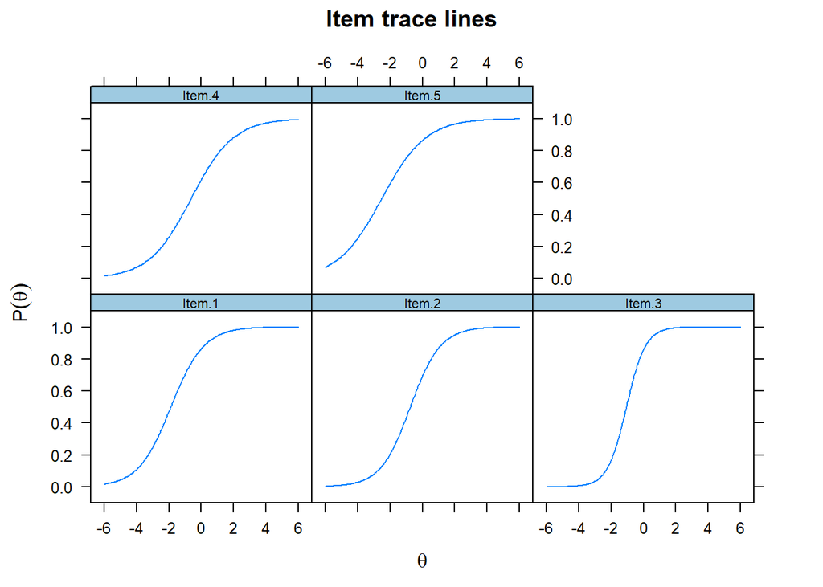

```r
plot(mirt_model, type = 'trace')
```

Nice curves. Let’s check *ltm* results:

```r
(ltm_model <- ltm(responses ~ z1, IRT.param = FALSE))
```

```
##
## Call:
## ltm(formula = responses ~ z1, IRT.param = FALSE)
##
## Coefficients:
##         (Intercept)     z1
## Item.1        1.856  0.988
## Item.2        0.808  1.081
## Item.3        1.805  1.707
## Item.4        0.486  0.765
## Item.5        1.855  0.736
##
## Log.Lik: -2658.805
```

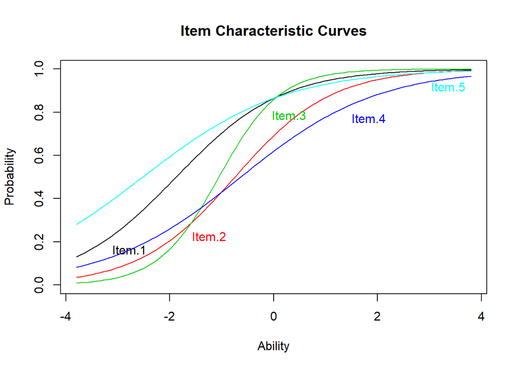

```r
plot(ltm_model)
```

It looks pretty similar.

## 100x5 matrix

Let’s take another random matrix:

```r
r = 100
c = 5
responses <- matrix(rbinom(r*c,1,0.5),r,c)
colnames(responses) <- paste0("item", c(1:c))
```

```r
head(responses)
```

```
##      item1 item2 item3 item4 item5
## [1,]     1     0     0     0     1
## [2,]     0     0     1     0     0
## [3,]     1     0     0     0     1
## [4,]     0     0     1     1     0
## [5,]     1     1     1     0     1
## [6,]     1     0     1     0     1
```

```r
colSums(responses)
```

```
## item1 item2 item3 item4 item5
##    52    43    46    54    58
```

```r
rowSums(responses)
```

```
##   [1] 2 1 2 2 4 3 3 4 1 2 2 3 5 2 1 4 3 0 2 1 1 3 4 2 3 4 4 2 0 3 3 2 0 5 1 2 3
##  [38] 3 2 3 1 0 2 2 4 1 4 3 2 4 2 2 4 3 4 2 3 3 2 3 2 3 1 4 2 2 2 1 4 3 4 3 3 2
##  [75] 1 1 3 2 5 4 1 1 3 3 2 2 4 3 2 4 3 2 3 3 3 2 1 4 3 4
```

```r
mirt_model <- mirt(responses, 1, SE=TRUE)
```

```r
coef(mirt_model)
```

```
## $item1
##             a1      d  g  u
## par      0.016  0.080  0  1
## CI_2.5  -0.659 -0.312 NA NA
## CI_97.5  0.691  0.472 NA NA
##
## $item2
##             a1      d  g  u
## par      0.433 -0.294  0  1
## CI_2.5  -0.364 -0.710 NA NA
## CI_97.5  1.229  0.121 NA NA
##
## $item3
##             a1      d  g  u
## par      0.890 -0.187  0  1
## CI_2.5  -0.398 -0.652 NA NA
## CI_97.5  2.177  0.278 NA NA
##
## $item4
##             a1      d  g  u
## par      1.183  0.206  0  1
## CI_2.5  -0.609 -0.310 NA NA
## CI_97.5  2.975  0.723 NA NA
##
## $item5
##             a1      d  g  u
## par     -0.741  0.362  0  1
## CI_2.5  -1.720 -0.093 NA NA
## CI_97.5  0.238  0.816 NA NA
##
## $GroupPars
##         MEAN_1 COV_11
## par          0      1
## CI_2.5      NA     NA
## CI_97.5     NA     NA
```

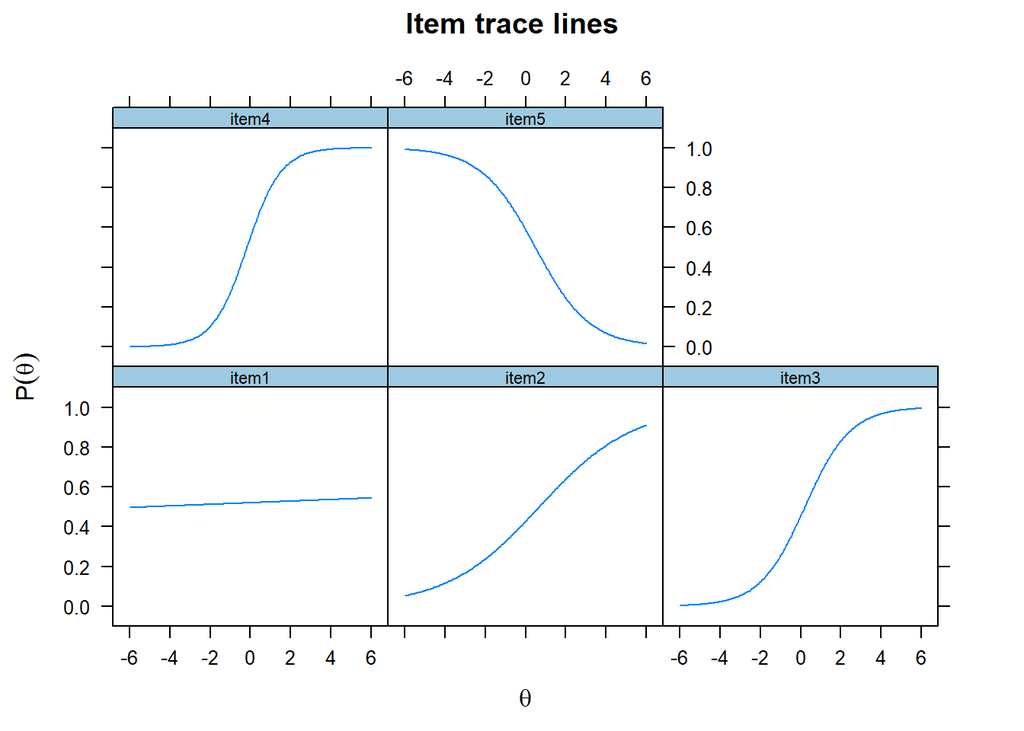

```r
plot(mirt_model, type = 'trace')
```

```r
(ltm_model <- ltm(responses ~ z1, IRT.param = FALSE))
```

```
##
## Call:
## ltm(formula = responses ~ z1, IRT.param = FALSE)
##
## Coefficients:
##        (Intercept)      z1
## item1        0.080   0.015
## item2       -0.294   0.433
## item3       -0.188   0.889
## item4        0.208   1.184
## item5        0.362  -0.741
##
## Log.Lik: -339.582
```

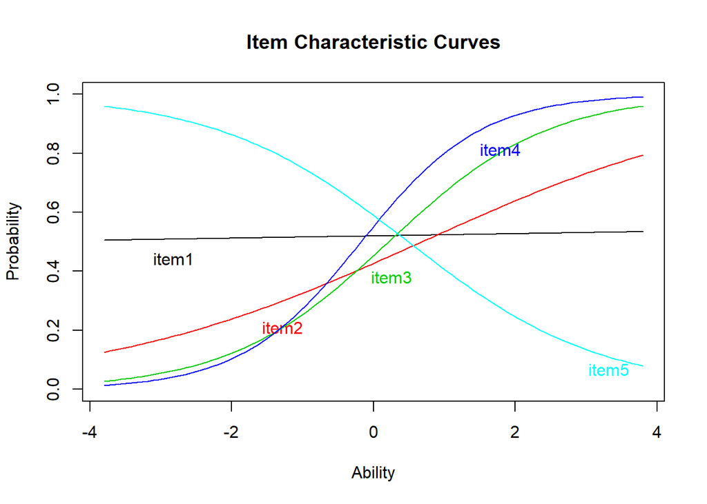

```r
plot(ltm_model)
```

Results from *mirt* and *ltm* are pretty similar.

## CDI data

Load already prepared data:

```r
responses_demo <- read.csv("Data/responses_demo.csv", encoding = "UTF-8")
cdi <- read.csv("Data/cdi.csv", encoding = "UTF-8")
responses <- as.matrix(responses_demo[,5:ncol(responses_demo)])
```

Create models of CDI data:

```r
ltm_model <- ltm(responses ~ z1, IRT.param = FALSE)
mirt_model <- mirt(responses, 1, SE = TRUE)
```

Look at some global fit statistics both from *ltm* and *mirt*

```r
mirt_model
```

```
##
## Call:
## mirt(data = responses, model = 1, SE = TRUE)
##
## Full-information item factor analysis with 1 factor(s).
## Converged within 1e-04 tolerance after 266 EM iterations.
## mirt version: 1.33.2
## M-step optimizer: BFGS
## EM acceleration: Ramsay
## Number of rectangular quadrature: 61
## Latent density type: Gaussian
##
## Information matrix estimated with method: Oakes
## Second-order test: model is a possible local maximum
## Condition number of information matrix =  122.3066
##
## Log-likelihood = -463630.5
## Estimated parameters: 1340
## AIC = 929941.1; AICc = 933700.3
## BIC = 937631.8; SABIC = 933374.4
## G2 (9999998660) = 892171.1, p = 1
## RMSEA = 0, CFI = NaN, TLI = NaN
```

```r
ltm_summary <- summary(ltm_model)
ltm_summary$logLik
```

```
## [1] -470030.7
```

```r
ltm_summary$AIC
```

```
## [1] 942741.3
```

```r
ltm_summary$BIC
```

```
## [1] 950432.1
```

Let’s look at parameters estimates from both models:

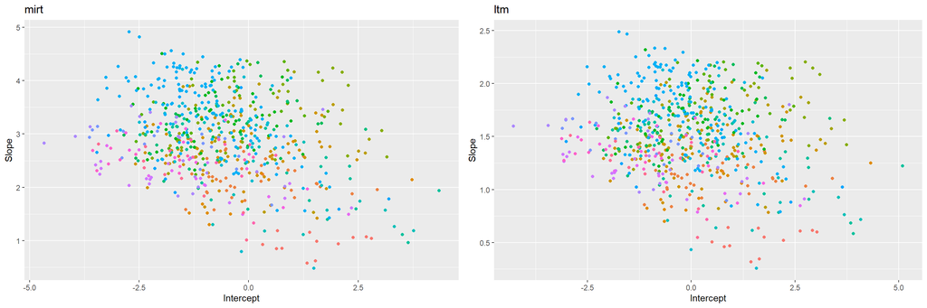

```r
mirt_params <- as.data.frame(coef(mirt_model, simplify = TRUE)$items)[1:2]
ltm_params <- as.data.frame(coef(ltm_model))
colnames(ltm_params) <- c("d", "z1")

mirt_params <- cbind(mirt_params, cdi)
ltm_params <- cbind(ltm_params, cdi)

mirt_plot <- ggplot(mirt_params, aes(d, a1, colour = category)) +
  geom_point() +
  xlab("Intercept") +
  ylab("Slope") +
  labs(title = "mirt") +
  theme(legend.position = "none")

ltm_plot <- ggplot(ltm_params, aes(d, z1, colour = category)) +
  geom_point() +
  xlab("Intercept") +
  ylab("Slope") +
  labs(title = "ltm") +
  theme(legend.position = "none")

ggarrange(mirt_plot, ltm_plot)
```

So in proper scale they look pretty similar. General order is preserved (points are coloured by categories).

Let’s set the same axes for both plots:

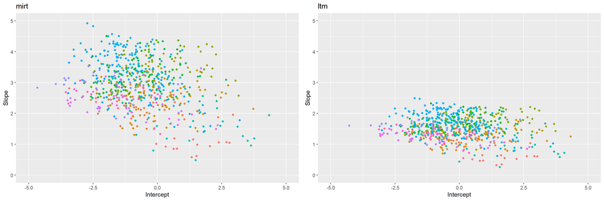

```r
mirt_plot <- ggplot(mirt_params, aes(d, a1, colour = category)) +
  geom_point() +
  xlab("Intercept") +
  ylab("Slope") +
  labs(title = "mirt") +
  theme(legend.position = "none") +
  xlim(-5,5) +
  ylim(0,5)

ltm_plot <- ggplot(ltm_params, aes(d, z1, colour = category)) +
  geom_point() +
  xlab("Intercept") +
  ylab("Slope") +
  labs(title = "ltm") +
  theme(legend.position = "none") +
  xlim(-5,5) +
  ylim(0,5)

ggarrange(mirt_plot, ltm_plot)
```

Now it’s visible that *ltm* params are somehow squished.

## Simulations

Let’s check how simulations will behave with *mirt* and *ltm* params.

### 10 items

```r
cl <- makeCluster(detectCores()) #Speeds up simulation
mirt_obj <- generate.mirt_object(mirt_params[1:2], '2PL')
```

```r
ltm_obj <- generate.mirt_object(data.frame(a1 = ltm_params$z1, d = ltm_params$d), '2PL')
```

```r
items_nr <- 10
design <- list(min_items = items_nr, max_items = items_nr)
results_mirt <- mirtCAT(mo = mirt_obj, method = "MAP", criteria = "MI", start_item = "MI", local_pattern = responses, cl = cl, design = design)
results_ltm <- mirtCAT(mo = ltm_obj, method = "MAP", criteria = "MI", start_item = "MI", local_pattern = responses, cl = cl, design = design)
```

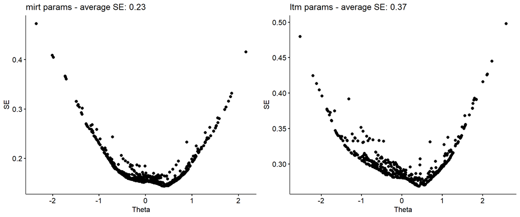

```r
thetas <- laply(results_mirt, function(x) x$thetas)
SE_thetas <- laply(results_mirt, function(x) x$SE_thetas)
plot_mirt <- ggscatter(data.frame(thetas, SE_thetas), y = "SE_thetas", x = "thetas",
                  xlab = "Theta", ylab = "SE", title = paste0("mirt params - average SE: ", round(mean(SE_thetas),2)))

thetas <- laply(results_ltm, function(x) x$thetas)
SE_thetas <- laply(results_ltm, function(x) x$SE_thetas)
plot_ltm<- ggscatter(data.frame(thetas, SE_thetas), y = "SE_thetas", x = "thetas",
                  xlab = "Theta", ylab = "SE", title = paste0("ltm params - average SE: ", round(mean(SE_thetas),2)))

ggarrange(plot_mirt, plot_ltm)
```

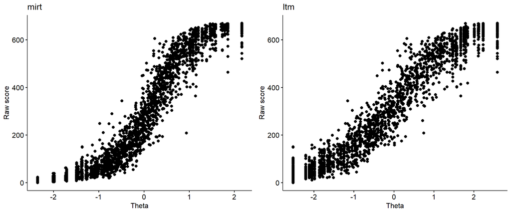

```r
raw_scores <- rowSums(responses)

thetas <- laply(results_mirt, function(x) x$thetas)
SE_thetas <- laply(results_mirt, function(x) x$SE_thetas)
plot_mirt <- ggscatter(data.frame(thetas, raw_scores), y = "raw_scores", x = "thetas",
          xlab = "Theta", ylab = "Raw score", title = "mirt")

thetas <- laply(results_ltm, function(x) x$thetas)
SE_thetas <- laply(results_ltm, function(x) x$SE_thetas)
plot_ltm <- ggscatter(data.frame(thetas, raw_scores), y = "raw_scores", x = "thetas",
          xlab = "Theta", ylab = "Raw score", title = "ltm")

ggarrange(plot_mirt, plot_ltm)
```

## 20 items

```r
items_nr <- 20
design <- list(min_items = items_nr, max_items = items_nr)
results_mirt <- mirtCAT(mo = mirt_obj, method = "MAP", criteria = "MI", start_item = "MI", local_pattern = responses, cl = cl, design = design)
results_ltm <- mirtCAT(mo = ltm_obj, method = "MAP", criteria = "MI", start_item = "MI", local_pattern = responses, cl = cl, design = design)
```

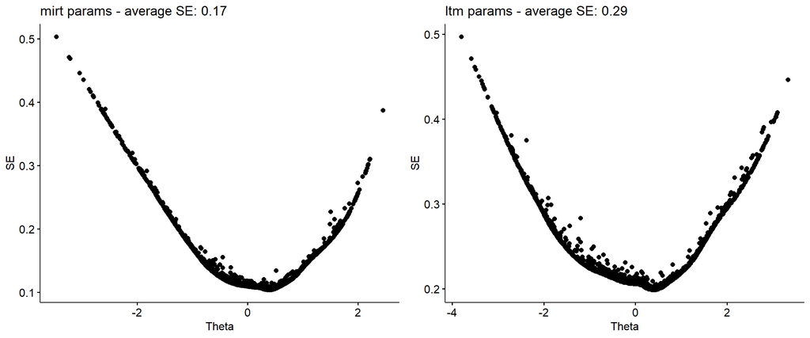

```r
thetas <- laply(results_mirt, function(x) x$thetas)
SE_thetas <- laply(results_mirt, function(x) x$SE_thetas)
plot_mirt <- ggscatter(data.frame(thetas, SE_thetas), y = "SE_thetas", x = "thetas",
                  xlab = "Theta", ylab = "SE", title = paste0("mirt params - average SE: ", round(mean(SE_thetas),2)))

thetas <- laply(results_ltm, function(x) x$thetas)
SE_thetas <- laply(results_ltm, function(x) x$SE_thetas)
plot_ltm<- ggscatter(data.frame(thetas, SE_thetas), y = "SE_thetas", x = "thetas",
                  xlab = "Theta", ylab = "SE", title = paste0("ltm params - average SE: ", round(mean(SE_thetas),2)))

ggarrange(plot_mirt, plot_ltm)
```

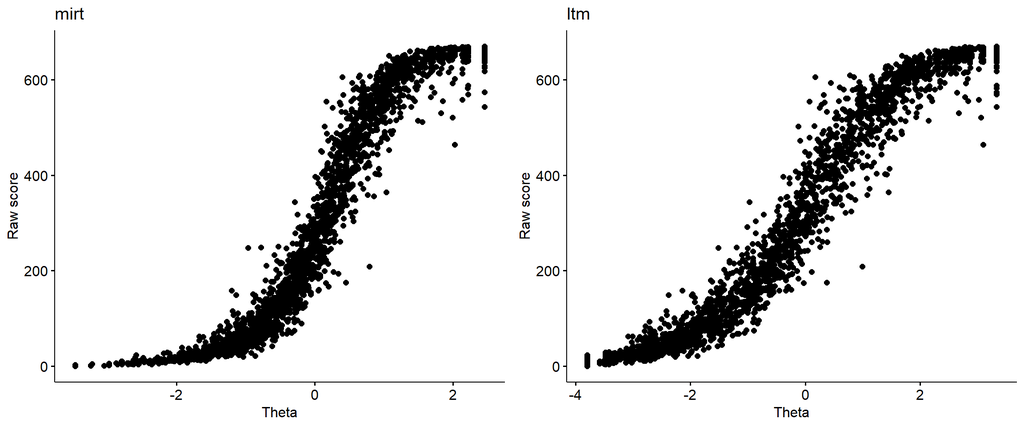

```r
thetas <- laply(results_mirt, function(x) x$thetas)
SE_thetas <- laply(results_mirt, function(x) x$SE_thetas)
plot_mirt <- ggscatter(data.frame(thetas, raw_scores), y = "raw_scores", x = "thetas",
          xlab = "Theta", ylab = "Raw score", title = "mirt")

thetas <- laply(results_ltm, function(x) x$thetas)
SE_thetas <- laply(results_ltm, function(x) x$SE_thetas)
plot_ltm <- ggscatter(data.frame(thetas, raw_scores), y = "raw_scores", x = "thetas",
          xlab = "Theta", ylab = "Raw score", title = "ltm")

ggarrange(plot_mirt, plot_ltm)
```